# Intro to GitHub-based workflows

## Let’s simplify things for now

- Most of us mostly use R
  - Ignore Python, Julia, etc.
- RStudio has tons of useful features
  - Ignore Terminal

Before getting to GitHub…

## Projects & directories

STOP using `setwd()` and `getwd()`

[figure not shown]

## Projects & directories

R Projects!

- Start viewing your projects as **modular** units
- RStudio optimised for project workflows (e.g., multiple sessions)

## Projects & directories

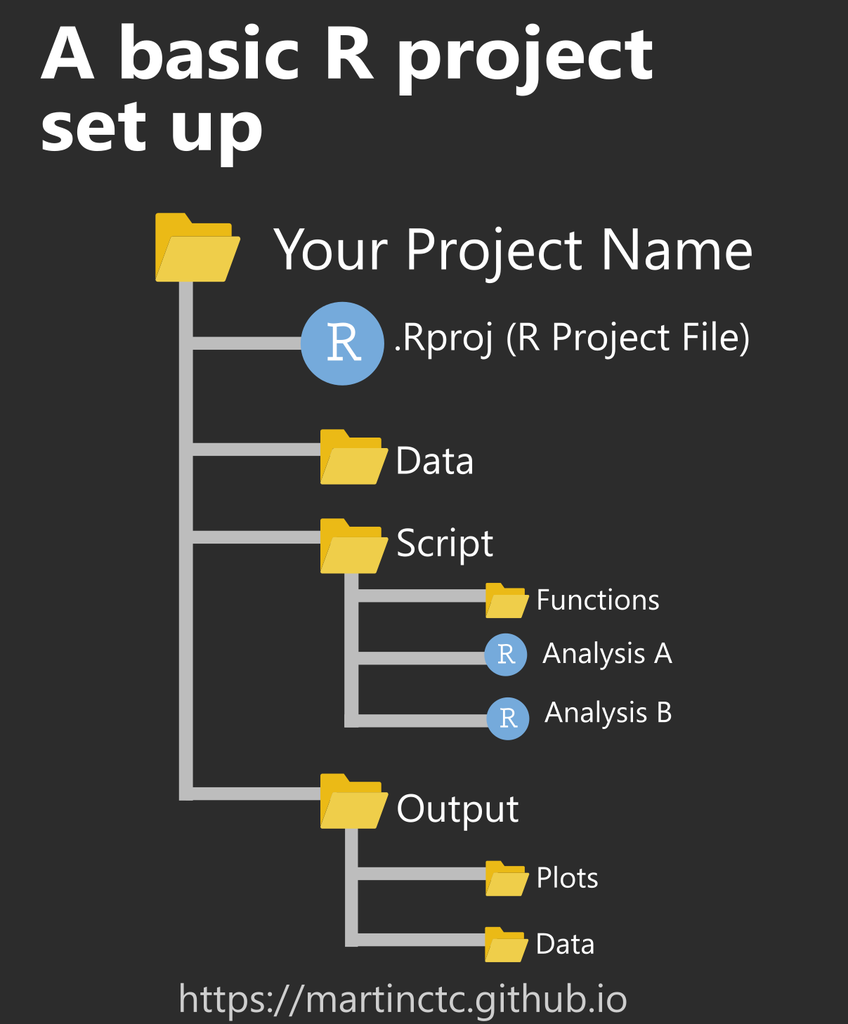

# Okay, GitHub…

[figure not shown]

1. Helping Future You
   - No idea what a script does?
   - Searchable log of project evolution
   - **Commits** force habit of documentation & **modularity**
2. Reproducibility as standard (journals, funders)
3. Structured time machine
   - No need to rebuild whole Jenga tower
4. Collaborating with safety net

Local work (saved files) = ideas in mind

Emailed files = coffee ramble

Git = jotted in personal notebook

GitHub = pages to hand out

[figure not shown]

## Git/GitHub concepts

- Repository
- Clones vs forks
- Commit-push-pull
- Diff
- Conflict
- Branch
- Pull request
- Issue
- …

# Repository

`github-intro`:

- https://github.com/montanolab/github-intro
- *Public* repository on *GitHub*
- Files/folders, commit history, repo details, settings, etc.
- Adding **collaborators** (public vs private repos)

## Clones vs forks

- How close are you to the project?
- Where do you want your changes to go?
  - *Whose hand-out pages? (GitHub thing)*
- Most cases: cloning

Collaborators, clone the repo!

# Commit-push-pull

Let me:

- Create a new empty R script in the `scripts/` folder
- Name it with my name: `script_karthik.R`
- Save the new script
- Open the `Git` panel in RStudio
  - Git sees my changes
  - Formalise changes with a commit
  - Share “news” with a push

Now one of you!

Always **pull before** working on new step!

So it becomes **pull-commit-push**

## `.gitignore`

Tell Git to turn a blind eye to certain files from the start

Triple-check before committing data files!

```r
# can ignore files
data/massive_data_file.xlsx

# but can also ignore folders
data_sensitive/

# or even all files of certain file type
*.pdf
*.docx
```

## Diff

Git sees everything, and can time travel within files!

What happens when I sign the README?

## Conflict

What happens when two people change the same thing?

Flavia, please sign the README and push your commit

Mismatch between local and remote

Let me try to push my signature

# Branch

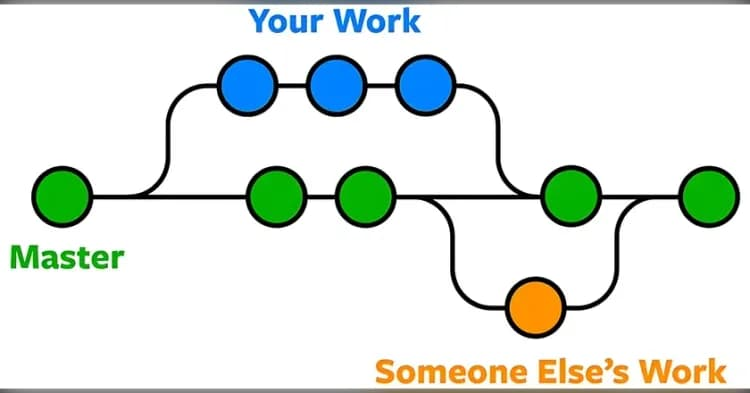

[figure not shown]

- Should be short-ish
- Main vs other: overall analysis vs finetuning model

## Pull request

- Let’s all branch out
- Create a branch with your name
- Create a script `script_NAME.R`
  - If already exists, modify slightly
- Commit with message “branch & PR practice (#1)”
- Push commit(s)
- PR: Transfer your completed work to “main” project

## Issue

- Planning project evolution
- Document changes under bigger picture (why?)
  - All the changes associated with one goal

## Git/GitHub concepts

- Repository
- Clones vs forks
- Commit-push-pull
- Diff
- Conflict
- Branch
- Pull request
- Issue
- …

## In practice

Peer review complete, [need to make changes](https://github.com/montanolab/github-intro/issues/2)

This time, reference #2 in commit messages

Let’s update (on our own branches) and view changes

Useful for reviewers too

## Branches should be managed well

Should be short-lived/temporary

```bash
git branch -D "karthik"
```

1. Helping Future You
   - No idea what a script does?
   - Searchable log of project evolution ([example](https://github.com/stateofindiasbirds/soib_2023))
   - **Commits** force habit of documentation & **modularity**
2. Reproducibility as standard (journals, funders)
3. Structured time machine
   - Jenga: no need to rebuild whole tower
4. Collaborating with safety net

[figure not shown]

- We can learn from more “mature” fields with time-tested best practices
- Overwhelm is not the solution
  - Hours into product, maximise impact
  - Mindset/value shift
  - Code review
  - Let’s learn by doing!

These are flexible guidelines, adapt over time